# EXPERIMENT 2: ASSOCIATION RULE MINING

#### The below flow chart shows the steps that were taken to run the whole experiment.

##### The algorithm used in this experiment to find the association rules is **"FPGrowth_association_rules"** algorithm.

We use the SPMF library to run the alforithm.

To RUN the algorithm:

1. If you are using the graphical interface,  
   (A) Choose the "FPGrowth_association_rules" algorithm,  
   (B) Select the input file (For e.g."Mining_input.txt"),  
   (C) set the output file name (e.g. "output.txt")  
   (D) set minsup = 25%, minconf= 100%  
   (E) click "Run algorithm".
2. If you want to execute this example from the command line, then execute this command:  
   *java -jar spmf.jar run FPGrowth_association_rules Miniing_input.txt output.txt 25 100% in a folder containing spmf.jar and the example input file contextIGB.txt.*

**ALGORITHM**  
It is an algorithm for discovering all association rules in a transaction database, following the two steps approach proposed by Agrawal & Srikant (1993). The first step is to discover frequent itemsets. The second step is to generate rules by using the frequent itemsets.

**INPUT**  
The input is a transaction database and two thresholds named minsup (a value between 0 and 1) and minconf (a value between 0 and 1).

**THE TRANSACTION DATABASE**  
A transaction database is a set of transactions. Each transaction is a set of distinct items. For example, consider the following transaction database. It contains 6 transactions (t1, t2, ..., t5, t6) and 5 items (1,2, 3, 4, 5). For example, the first transaction represents the set of items 1, 2, 4 and 5. This database is provided as the file contextIGB.txt in the SPMF distribution. It is important to note that an item is not allowed to appear twice in the same transaction and that items are assumed to be sorted by lexicographical order in a transaction.

[output not shown]

**OUTPUT**  
The output of an association rule mining algorithm is a set of association rules respecting the user-specified minsup and minconf thresholds.  
An **association rule** X==>Y is a relationship between two itemsets (sets of items) X and Y such that the intersection of X and Y is empty.  
The **support** of a rule is the number of transactions that contains X∪Y.  
The **confidence** of a rule is the number of transactions that contains X∪Y divided by the number of transactions that contain X.

**RULE**  
Di=>Dj

**SUPPORT** $Freq(Di,Dj)/N$

**CONFIDENCE**  
$Freq(Di,Dj)/Freq(Di)$

If we apply an association rule mining algorithm, it will return all the rules having a support and confidence respectively no less than minsup and minconf.

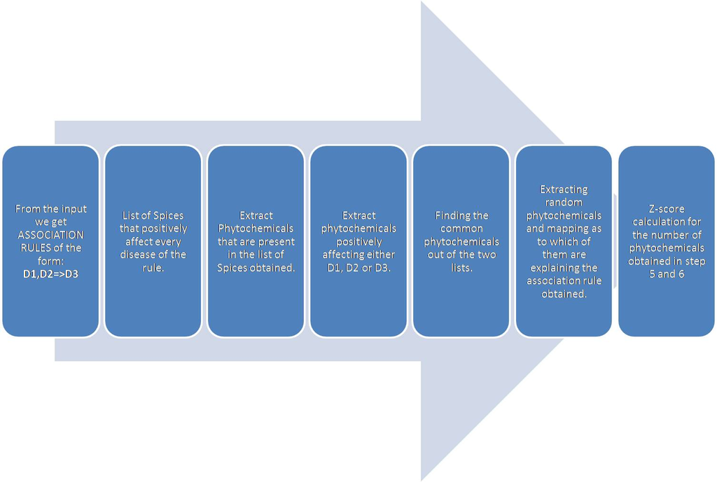

```python
from IPython.display import Image
Image(filename='Flowchart.jpg')
```

```python
#The below code is the first code that maps the spice-disease associations to numbers forming EDGE file.

class Spice:
    def __init__(self, id, name):
        self.id = id
        self.name = name


class Disease:
    def __init__(self, id, name):
        self.id = id
        self.name = name


my_file = open('level-3-asssociations.tsv','r')
lines = my_file.readlines()

spices = []
diseases = []
for line in lines:
    temp_list = line.split('\t')
    spices.append(temp_list[1])
    diseases.append(temp_list[3])

# spices.pop(0)
# diseases.pop(0)
spices = list(set(spices))
diseases = list(set(diseases))



spice_mapped_list = []
i = 1
for s in spices:
    spice = Spice(i, s)
    spice_mapped_list.append(spice)
    i += 1


disease_mapped_list = []
i = len(spices) + 1
for d in diseases:
    disease = Disease(i, d)
    disease_mapped_list.append(disease)
    i += 1

j = 0
for s in spice_mapped_list:
    if j == 0:
        my_spice_file = open('Spice(1-148).txt', 'w')
        my_spice_file.write(str(s.id) + ' ' + s.name + '\n')
        j += 1
    else:
        my_spice_file = open('Spice(1-148).txt', 'a')
        my_spice_file.write(str(s.id) + ' ' + s.name + '\n')
j = 0
for d in disease_mapped_list:
    if j == 0:
        my_spice_file = open('Disease(149-610).txt', 'w')
        my_spice_file.write(str(d.id) + ' ' + d.name + '\n')
        j += 1
    else:
        my_spice_file = open('Disease(149-610).txt', 'a')
        my_spice_file.write(str(d.id) + ' ' + d.name + '\n')

edge = []
for line in lines:
    temp_list = line.split('\t')
    spice_name = temp_list[1]
    disease_name = temp_list[3]
    if spice_name == 'Spice' and disease_name == 'Disease':
        continue
    for s in spice_mapped_list:
        if s.name == spice_name:
            spice_id = s.id
            break
    for d in disease_mapped_list:
        if d.name == disease_name:
            disease_id = d.id
            break
    el = []
    el.append(spice_id)
    el.append(disease_id)
    edge.append(el)

j = 0
for e in edge:
    if j == 0:
        my_edge_file = open('Edge(spice 1-148).txt', 'w')
        my_edge_file.write(str(e[0]) + ' ' + str(e[1]) + '\n')
        j += 1
    else:
        my_edge_file = open('Edge(spice 1-148).txt', 'a')
        my_edge_file.write(str(e[0]) + ' ' + str(e[1]) + '\n')
```

```python
import numpy as np
data= np.loadtxt('Edge(spice 1-148).txt')
print(data)
```

```
[[ 120.  194.]
 [ 139.  194.]
 [  76.  194.]
 ...,
 [  18.  157.]
 [  41.  157.]
 [  50.  157.]]
```

#### INPUT FILE FORMAT:

The input file format is a text file containing transactions. Each lines represents a transaction. The items in the transaction are listed on the corresponding line. An item is represented by a positive integer. Each item is separated from the following item by a space. It is assumed that items are sorted according to a total order and that no item can appear twice in the same transaction. For example, for the previous example, the input file is defined as follows:

1 2 4 5  
2 3 5  
1 2 4 5  
1 2 3 5  
1 2 3 4 5  
2 3 4

Consider the first line. It means that the first transaction is the itemset {1, 2, 4 and 5}. The following lines follow the same format.

```python
## The below code is used to covert the EDGE file in the form of transactions.
edgefile = open("Edge(spice 1-148).txt",'r')
edgeread = edgefile.readlines()
j = 0
for i in range(1,149):
    diseaselist=[]
    for edge in edgeread:
        edgelist = edge.split()
        if(i == int(edgelist[0])):
            diseaselist.append(edgelist[1])

    if(j == 0):
        edgewrite = open("Mining_input.txt", 'w')
        diseaselist = list(set(diseaselist))
        for spice in diseaselist:
            edgewrite.write(str(spice) + " ")
        edgewrite.write("\n")
        j += 1
    else:
        edgewrite = open("Mining_input.txt", 'a')
        diseaselist = list(set(diseaselist))
        for spice in diseaselist:
            edgewrite.write(str(spice) + " ")
        edgewrite.write("\n")
```

The Transaction file that we get have:  
Each transaction corresponding to a **SPICE**.  
Items are anlogous to **DISEASES**.  
As shown below:

| Spice | Diseases |
| --- | --- |
| 1 | 596 484 314 583 520 602 |
| 2 | 194 |
| 3 | 176 428 418 533 241 403 245 373 168 377 347 451 194 608 371 |
| 4 | 418 243 150 278 379 240 321 451 201 579 339 527 561 267 401 556 371 368 498 547 347 236 |
| 5 | 547 220 278 |
| 6 | 579 267 406 |

```python
import numpy as np
data= np.loadtxt('Mining_input.txt', delimiter = '\t' , dtype = str , comments = None)
print(data)
```

[output not shown]

```python
## The below plot helps us decide the cuttoff of the support that we can apply.
## We can observe that after 13% the number of associations drastically increase.

import plotly.plotly as py
from plotly.graph_objs import *
import plotly
import plotly.plotly as py
import plotly.figure_factory as ff
import pandas as pd
import plotly.graph_objs as go

plotly.tools.set_credentials_file(username='akshita17143', api_key='lEzWov2Hr4N7UqlIxkWG')

df1 = pd.read_csv('support vs #association_rules1.csv', sep = ',')
data1 = [go.Scatter(y=df1.Rules,
            x=df1.Min_support)]
layout1 = Layout(title="Spice_count vs Disease_count",
                yaxis=dict(title='Rules'),
                xaxis=dict(title='Min_support'))
fig1 = Figure(data = data1, layout=layout1)

py.iplot(fig1, filename='supvsasso')
```

[interactive chart not shown]

[figure not shown]

```python
## We then use the INput file and run the SPMF Library as shown below:
from IPython.display import Image
Image(filename='spmf.png')
```

#### OUTPUT FILE FORMAT:

The output file format is defined as follows.  
It is a text file, where each line represents an association rule. On each line, the items of the rule antecedent are first listed. Each item is represented by an integer, followed by a single space. After, that the keyword "==>" appears followed by a space. Then, the items of the rule consequent are listed. Each item is represented by an integer, followed by a single space. Then, the keyword " #SUP: " appears followed by the support of the rule represented by an integer. Then, the keyword " #CONF: " appears followed by the confidence of the rule represented by a double value (a value between 0 and 1, inclusively). For example, here is a few lines from the output file for this example:

1 ==> 2 4 5 #SUP: 3 #CONF: 0,75  
5 ==> 1 2 4 #SUP: 3 #CONF: 0,6  
4 ==> 1 2 5 #SUP: 3 #CONF: 0,75

For example, the first line indicates that the association rule {1} --> {2, 4, 5} has a support of 3 transactions and a confidence of 75 %. The other lines follow the same format.

```python
import numpy as np
data= np.loadtxt('out_25_1.txt', delimiter = '\t' , dtype = str , comments = None)
print(data)
```

```
['320 ==> 201 #SUP: 42 #CONF: 1.0' '321 ==> 240 #SUP: 42 #CONF: 1.0'
 '579 ==> 267 #SUP: 44 #CONF: 1.0' '278 ==> 547 #SUP: 38 #CONF: 1.0'
 '353 ==> 300 #SUP: 39 #CONF: 1.0' '401 ==> 368 #SUP: 42 #CONF: 1.0'
 '320 602 ==> 201 #SUP: 37 #CONF: 1.0']
```

```python
## The below code demaps the output rules to their respective diseases.

association_set_file = open('out_25_1.txt','r')
disease_file = open("Disease(149-610).txt", 'r')
association_set_read = association_set_file.readlines()
disease_file_read = disease_file.readlines()
associationset_list = []
for association_sets in association_set_read:
    string = ''
    association_set_list = association_sets.split('#')
    association_set = association_set_list[0].split("==>")
    for association in association_set[0].split(" "):
        if association != ' ':
            for disease in disease_file_read:
                disease_list = disease.split(" ",1)
                if association.rstrip(" ") == disease_list[0]:
                    string += disease_list[1].rstrip('\n')
                    string += ";"
    string = string.rstrip(";") + " ==> "
    for association in association_set[1].split(" "):
        if association != ' ':
            for disease in disease_file_read:
                disease_list = disease.split(" ",1)
                if association.rstrip(" ") == disease_list[0]:
                    string += disease_list[1].rstrip('\n')
                    string += ";"
    string = string.rstrip(";") + ", "+ association_set_list[1] + ", " + association_set_list[2]
    associationset_list.append(string)

write_associationsets = open("out(.25-1)demap.txt", 'w')
for associations in associationset_list:
    write_associationsets.write(associations)
```

```python
import numpy as np
data= np.loadtxt('out(.25-1).txt', delimiter = '\t' , dtype = str , comments = None)
print(data)
```

```
['Kidney Diseases ==> Urologic Diseases, SUP: 38 , CONF: 1.0'
 'Pain ==> Neurologic Manifestations, SUP: 42 , CONF: 1.0'
 'Overnutrition ==> Body Weight, SUP: 42 , CONF: 1.0'
 'Carcinogenesis ==> Neoplastic Processes, SUP: 39 , CONF: 1.0'
 'Gastrointestinal Neoplasms ==> Digestive System Neoplasms, SUP: 42 , CONF: 1.0'
 'Breast Neoplasms ==> Breast Diseases, SUP: 44 , CONF: 1.0'
 'Intestinal Diseases;Gastrointestinal Neoplasms ==> Digestive System Neoplasms, SUP: 37 , CONF: 1.0']
```

```python
## The below code is used to show the zscore-test after all the mappings.

import itertools
import random
import math

iterations = 100

file_association_rules = open('out(.25-1).txt', 'r')
rule_lines = file_association_rules.readlines()

sd_dict = {}
file_disease_to_spice = open('Spice_disease.tsv', 'r')
sd_lines = file_disease_to_spice.readlines()
for sd_line in sd_lines:
    temp = sd_line.split('\t')
    if temp[3].strip() in sd_dict:
        list_of_spices = sd_dict.get(temp[3].strip())
        list_of_spices.append(temp[1].strip())
        list_of_spices = list(set(list_of_spices))
        sd_dict[temp[3].strip()] = list_of_spices
    else:
        list_of_spices = []
        list_of_spices.append(temp[1].strip())
        sd_dict[temp[3].strip()] = list_of_spices

i = 0
dp_dict = {}
file_disease_to_phyto = open('Disease_to_phytochemical.tsv', 'r')
dp_lines = file_disease_to_phyto.readlines()
for dp_line in dp_lines:
    if i != 0:
        temp = dp_line.split('\t')
        if temp[4] in dp_dict:
            list_of_phyto = dp_dict.get(temp[4])
            list_of_phyto.append(temp[2].strip())
            list_of_phyto = list(set(list_of_phyto))
            dp_dict[temp[4]] = list_of_phyto
        else:
            list_of_phyto = []
            list_of_phyto.append(temp[2].strip())
            dp_dict[temp[4]] = list_of_phyto
    i += 1

j = 0
sp_dict = {}
sp_list = []
file_spice_to_phyto = open('Spice_to_phytochemical.tsv', 'r')
sp_lines = file_spice_to_phyto.readlines()
for sp_line in sp_lines:
    if j != 0:
        temp = sp_line.split('\t')
        if temp[0].strip() in sp_dict:
            list_of_phyto = sp_dict.get(temp[0].strip())
            list_of_phyto.append(temp[1].strip())
            sp_list.append(temp[1].strip())
            list_of_phyto = list(set(list_of_phyto))
            sp_dict[temp[0].strip()] = list_of_phyto
        else:
            list_of_phyto = []
            list_of_phyto.append(temp[1].strip())
            sp_list.append(temp[1].strip())
            sp_dict[temp[0].strip()] = list_of_phyto
    j += 1
sp_list = list(set(sp_list))

def get_phytochemical_count_after_mapping_to_spices(diseases, phyto_list):
    list_to_be_returned = []
    for phyto in phyto_list:
        flag = 0
        for disease in diseases:
            if disease in dp_dict:
                p_list = dp_dict.get(disease)
                if phyto not in p_list:
                    flag = 1
                    #list_to_be_returned.append(phyto)
                    break
            else:
                flag = 1
                break
        if flag == 0:
            list_to_be_returned.append(phyto)
    return list_to_be_returned

s_list = []
pc_list = []
zscore_list = []
for line in rule_lines:
    temp_list = line.split(' ==> ')
    temp_list_lhs = temp_list[0].split(';')
    temp_list_rhs = temp_list[1].split(', SUP')[0].split(';')
    diseases = temp_list_lhs + temp_list_rhs
    all_spices = []
    phytochemicals_from_spices = []
    phytochemicals_checked_from_diseases = []
    for disease in diseases:
        all_spices.append(sd_dict.get(disease))
    all_spices = list(set(list(itertools.chain.from_iterable(all_spices))))
    for spice in all_spices:
        if spice in sp_dict:
            extracted_phytochemical_list = sp_dict[spice]
            for pc in extracted_phytochemical_list:
                phytochemicals_from_spices.append(pc)
    phytochemicals_from_spices = list(set(phytochemicals_from_spices))

    # ZScore calculation
    mapped_phyto = get_phytochemical_count_after_mapping_to_spices(diseases, phytochemicals_from_spices)
    biological_count = len(mapped_phyto)
    number_of_random_samples = len(phytochemicals_from_spices)

    rand_list = []
    for k in range(0, iterations):
        phytochemicals_from_random_pick = []
        while len(phytochemicals_from_random_pick) != number_of_random_samples:
            phytochemicals_from_random_pick.append(random.choice(sp_list))
            phytochemicals_from_random_pick = list(set(phytochemicals_from_random_pick))
        mapped_random_phyto = get_phytochemical_count_after_mapping_to_spices(diseases, phytochemicals_from_random_pick)
        rand_list.append(len(mapped_random_phyto))
    list_sum = 0
    for elt in rand_list:
        list_sum += int(elt)
    mean = list_sum*1.0/iterations

    numerator = 0
    for elt in rand_list:
        numerator += (elt-mean)*(elt-mean)
    denominator = iterations-1
    std = math.sqrt(numerator*1.0/denominator)
    if std != 0:
        zscore = ((biological_count - mean)*1.0)/std
    else:
        zscore = 0
    zscore_list.append(zscore)

    sp = ''
    counter = 0
    for spice in all_spices:
        if counter != len(all_spices) - 1:
            sp += spice + ', '
        else:
            sp += spice + '->' + str(len(all_spices)) + '\n'
        counter += 1
    s_list.append(sp)
    pc = ''
    counter = 0
    for phyto in mapped_phyto:
        if counter != len(mapped_phyto) - 1:
            pc += phyto + ', '
        else:
            pc += phyto + '->' + str(len(mapped_phyto)) + '\n'
        counter += 1
    pc_list.append(pc)

output_file = open('Zscore.txt', 'w')
for it in range(0, len(zscore_list)):
    output_file.write(rule_lines[it] + '\n' + s_list[it] + pc_list[it] + str(zscore_list[it]) + '\n' + '\n')
```

```python
# In this we have calculated the Zscore as well which is considered as extra information and was more than needed.
import numpy as np
data= np.loadtxt('Zscore(intersection).txt', delimiter = '\t' , dtype = str , comments = None)
print(data)
```

```
[ 'Gastrointestinal Neoplasms ==> Digestive System Neoplasms, SUP: 42 , CONF: 1.0'
 'Origanum vulgare, Cuminum cyminum, Portulaca oleracea, Alkanna tinctoria, Juniperus communis, Artemisia dracunculus, Ferula assa-foetida, Glycyrrhiza glabra, Sesamum indicum, Mentha spicata, Thymus vulgaris, Apium graveolens, Myristica fragrans, Backhousia myrtifolia, Gynostemma pentaphyllum, Arte…
 'D019833, D003474, C013015, C040920, D009638, C002503, C028009, C045651, D005054, C008661, D047310, D011794, C007836, C042577, C002979->15'
 '1.744621434286976'
 'Pain ==> Neurologic Manifestations, SUP: 42 , CONF: 1.0'
 'Origanum vulgare, Alpinia officinarum, Chamaemelum nobile, Cuminum cyminum, Cinnamomum verum, Abelmoschus moschatus, Cinnamomum aromaticum, Piper nigrum, Capsicum frutescens, Eryngium foetidum, Glycyrrhiza glabra, Sesamum indicum, Oenothera biennis, Myristica fragrans, Satureja hortensis, Achillea…
 'D000376, D000241, C019286, C007210, D008610, D006139, C013015, D005054, C073316, D011794, C012526->11'
 '-0.7873752262936797'
 'Breast Neoplasms ==> Breast Diseases, SUP: 44 , CONF: 1.0'
 'Origanum vulgare, Alpinia officinarum, Chamaemelum nobile, Linum usitatissimum, Chamerion angustifolium, Piper nigrum, Cinnamomum aromaticum, Matricaria chamomilla, Juniperus communis, Capsicum frutescens, Ferula assa-foetida, Glycyrrhiza glabra, Sesamum indicum, Pimenta dioica, Oenothera biennis,…
 'D019833, D002392, C038491, C057996, D019301, D003474, C040920, C006552, C023623, C045651, D005054, C002070, D047310, D011794, C042577, C007845->16'
 '2.859173315115352'
 'Kidney Diseases ==> Urologic Diseases, SUP: 38 , CONF: 1.0'
 'Alpinia officinarum, Borago officinalis, Hibiscus sabdariffa, Cinnamomum verum, Linum usitatissimum, Cinnamomum aromaticum, Matricaria chamomilla, Glycyrrhiza glabra, Sesamum indicum, Piper cubeba, Apium graveolens, Oenothera biennis, Myristica fragrans, Foeniculum vulgare, Carum carvi, Ocimum ten…
 'C005274, D005707, D047311, D009828, C038491, D000241, C005273, C029010, D012431, C005246, D008353, D003474, C008324, C040015, D019695, D008715, C029036, C028009, C045651, C030123, C059006, D011794, D008730, C003466, D004610, C007768->26'
 '0.08092961883246798'
 'Carcinogenesis ==> Neoplastic Processes, SUP: 39 , CONF: 1.0'
 'Origanum vulgare, Bixa orellana, Cinnamomum verum, Piper nigrum, Capsicum frutescens, Ferula assa-foetida, Glycyrrhiza glabra, Sesamum indicum, Pimpinella anisum, Apium graveolens, Myristica fragrans, Garcinia indica, Artemisia absinthium, Elettaria cardamomum, Foeniculum vulgare, Perilla frutesce…
 'D047311, D002392, C000596494, C005466, C040015, C006552, C016527, D011794, C042577, C032005, D004610->11'
 '1.7500375935811692' 'Overnutrition ==> Body Weight, SUP: 42 , CONF: 1.0'
 'Alpinia officinarum, Chamaemelum nobile, Hibiscus sabdariffa, Cuminum cyminum, Cinnamomum verum, Portulaca oleracea, Linum usitatissimum, Cinnamomum aromaticum, Piper nigrum, Camellia oleifera, Capsicum frutescens, Ferula assa-foetida, Glycyrrhiza glabra, Piper longum, Myristica fragrans, Gynostem…
 'C032171, D009828, C005273, D003474, D011794, C107601->6'
 '1.9871401637570951'
 'Gastrointestinal Neoplasms;Intestinal Diseases ==> Digestive System Neoplasms, SUP: 37 , CONF: 1.0'
 'Origanum vulgare, Cuminum cyminum, Portulaca oleracea, Alkanna tinctoria, Juniperus communis, Ferula assa-foetida, Glycyrrhiza glabra, Mentha spicata, Thymus vulgaris, Apium graveolens, Myristica fragrans, Backhousia myrtifolia, Foeniculum vulgare, Mentha x piperita, Crocus sativus, Trigonella foe…
 'D019833, D003474, C013015, C040920, C002503, C028009, C045651, D005054, C008661, D047310, D011794, C007836, C002979->13'
 '1.389071666970716']
```